# Assignment 1

Mel Miller

9/15/2020

# Preparing the Dataset

To create my dataset to use for this assignment, I first loaded the following libraries:

```r
library (ggplot2)
library (ggthemes)
library (tidycensus)
library (tidyverse)

person_vars_2018 <- pums_variables %>%
  distinct(year, survey, var_code,
           var_label, data_type, level) %>%
  filter(level == "person", year == 2018, survey == "acs1")
```

For this assignment, I used a truncated dataset based on the one I created for Quant Assignment 1. I selected the following 6 variables, which are all filtered for older adults (age 65 and older) in Massachusetts:

1. Age (AGEP)
2. Sex (SEX)
3. Race (RAC1P)
4. Housing tenure (TEN)
5. Total income, past 12 months (PINCP)
6. Household size (NP)

The first 10 rows of my data are shown below. You’ll notice the variable for race (RAC1P) is included twice in the code below. As you’ll see shortly, I included this twice so that I would be able to recode it into a new variable.

```r
person_data
```

```
## # A tibble: 13,822 x 7
##     AGEP SEX_label RAC1P_label RAC1P TEN_label       PINCP    NP
##    <dbl> <chr>     <chr>       <chr> <chr>           <dbl> <dbl>
##  1    90 Female    White alone 1     N/A (GQ/vacant) 10500     1
##  2    89 Female    White alone 1     N/A (GQ/vacant) 30600     1
##  3    90 Female    White alone 1     N/A (GQ/vacant) 22600     1
##  4    85 Female    White alone 1     N/A (GQ/vacant)     0     1
##  5    86 Female    White alone 1     N/A (GQ/vacant)  6300     1
##  6    86 Male      White alone 1     N/A (GQ/vacant) 36600     1
##  7    85 Female    White alone 1     N/A (GQ/vacant) 21100     1
##  8    74 Female    White alone 1     N/A (GQ/vacant) 22000     1
##  9    90 Female    White alone 1     N/A (GQ/vacant)     0     1
## 10    89 Male      White alone 1     N/A (GQ/vacant)     0     1
## # ... with 13,812 more rows
```

# Visualizing the Data

Using this dataset, I created 13 charts. These charts are categorized into the ten sections that follow.

## 1. Pie charts: Race and housing tenure

I ran two pie charts to serve as an introduction to my dataset. The first is for race, and the second is for housing tenure. In both charts there are clear majorities: White for race, and owning for housing tenure (owning free and clear, followed by owning with mortgage or loan). For the second race group, the full label is as follows: “American Indian and Alaska Native tribes specified; or American Indian or Alaska Native, not specified and no other races.”

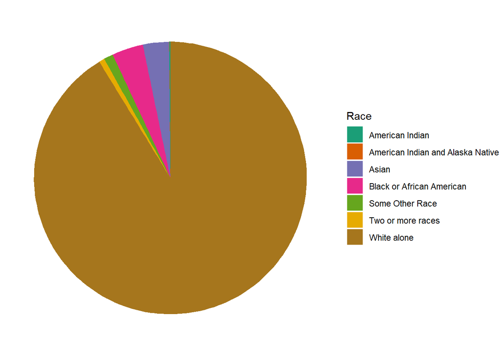

```r
pie_chart <- ggplot(person_data, aes(x = 1, fill = RAC1P_label)) +
  geom_bar(position = "fill") +
  coord_polar(theta = "y") +
  scale_y_continuous(name = "Number of people") +
  scale_fill_brewer(name= "Race",
                    labels = c("American Indian",
                               "American Indian and Alaska Native",
                               "Asian",
                               "Black or African American",
                               "Some Other Race",
                               "Two or more races",
                               "White alone"),
                    palette="Dark2")+
  theme_void()

pie_chart
```

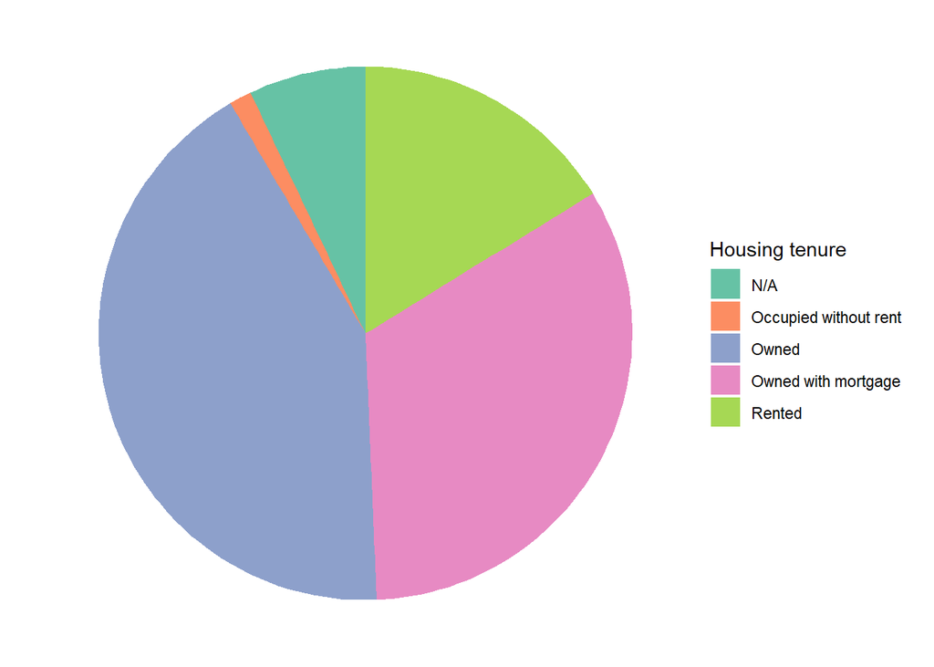

```r
pie_chart <- ggplot(person_data, aes(x = 1, fill = TEN_label)) +
  geom_bar(position = "fill") +
  coord_polar(theta = "y") +
  scale_y_continuous(name = "Number of people") +
  scale_fill_brewer (name = "Housing tenure",
                     labels = c("N/A",
                               "Occupied without rent",
                               "Owned",
                               "Owned with mortgage",
                               "Rented"),
                    palette="Set2") +
  theme_void()

pie_chart
```

### Recoding values

After seeing the breakdown of race data in this dataset, I recoded this variable into: White, Black or African American, Asian, and Other. Even though this recoding collapses important categories, I believe simplifying the data in this way helps with this and other visualizations that use this variable.

```r
person_data <- as.data.frame(person_data)

person_data$scode [person_data$RAC1P=="1"] <- "White"
person_data$scode [person_data$RAC1P=="2"] <- "Black"
person_data$scode [person_data$RAC1P=="6"] <- "Asian"
person_data$scode [person_data$RAC1P=="3"] <- "Other"
person_data$scode [person_data$RAC1P=="5"] <- "Other"
person_data$scode [person_data$RAC1P=="8"] <- "Other"
person_data$scode [person_data$RAC1P=="9"] <- "Other"

colnames(person_data)[colnames(person_data) == 'scode'] <- "Race"
```

### Pie chart: Race recoded

The pie chart for the recoded race variable represents the previously mentioned four categories.

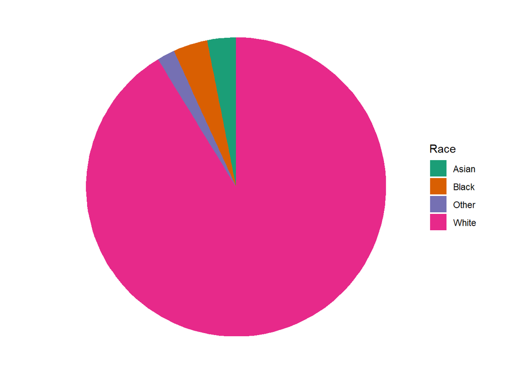

```r
pie_chart <- ggplot(person_data, aes(x = 1, fill = Race)) +
  geom_bar(position = "fill") +
  coord_polar(theta = "y") +
  scale_y_continuous(name = "Number of people") +
  scale_fill_brewer(name = "Race",
                    palette="Dark2") +
  theme_void()

pie_chart
```

## 2. Scatter plot with trendline: Household size by age

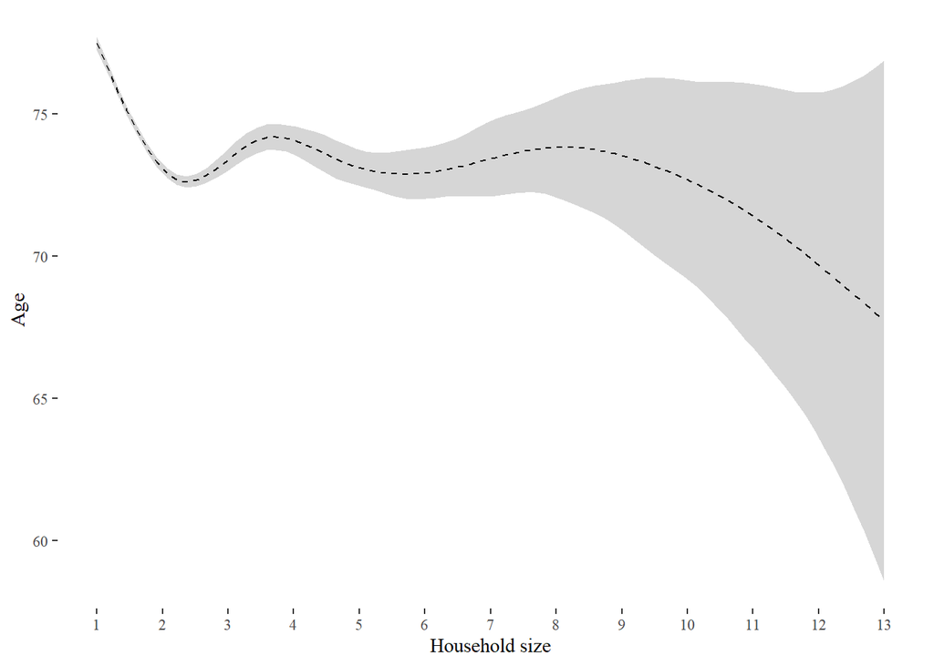

```r
ggplot(person_data,
       aes(x = NP,
           y = AGEP)) +
  stat_smooth(color = "black", linetype = 2, size = 0.5) +
  scale_x_continuous(name = "Household size",
                     breaks = seq(1, 20, by = 1)) +
  scale_y_continuous(name = "Age",
                     breaks = seq(60, 100, by = 5)) +
  theme_tufte()
```

## 3. Scatter plot with multiple trendlines: Household size by race

This scatter plot differs by the previous figure in several ways. First, it shows the actual point data, which I had removed from the previous figure. This chart also incorporates race, enabling viewers to conceptualize the relationship with household size, age, and race. As with the previous graph, here we see that household size decreases with age. We also see this relationship in terms of race, with what I believe the clearest take away is that the number of people in household decreases with age the most for White people.

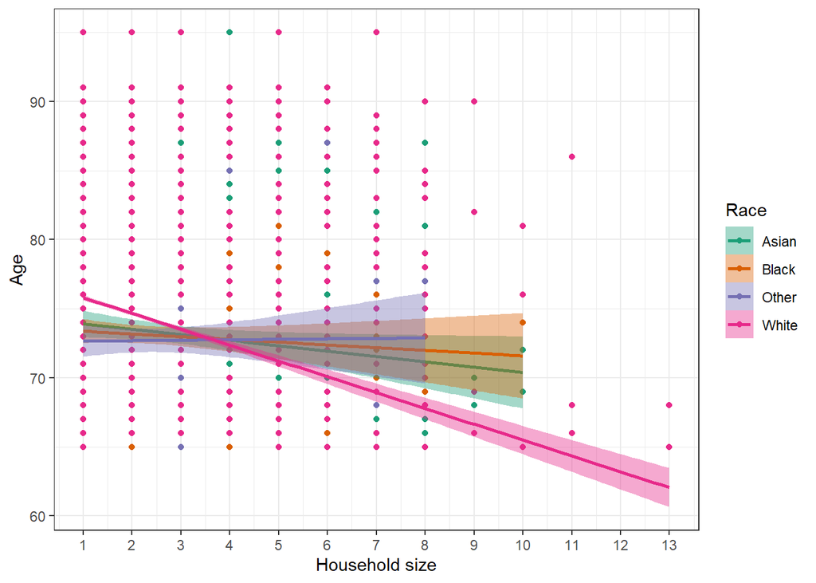

```r
ggplot(person_data,
       aes(x = NP,
           y = AGEP,
           color = Race,
           fill = Race)) +
  geom_point() +
  stat_smooth(method = "lm") +
  scale_x_continuous(name = "Household size",
                     breaks = seq(0, 15, by = 1)) +
  scale_y_continuous(name = "Age",
                     breaks = seq(60, 100, by = 10)) +
  scale_fill_brewer(name = "Race",
                    palette="Dark2") +
  scale_color_brewer(name = "Race",
                    palette="Dark2") +
  theme_bw()
```

## 4. Box plot: Housing tenure by age

I believe this box plot provides the best summary of the data so far. Here we see that, on average, those who own their home with a mortgage are younger than any other housing tenure group, while those who indicated “N/A” for their housing tenure are the oldest. While I was initially not sure what this “N/A” group represented, this chart makes me think it may be individuals who live in assisted living communities who, even though they usually pay rent, this housing tenure is different than the typical conception of “renting.”

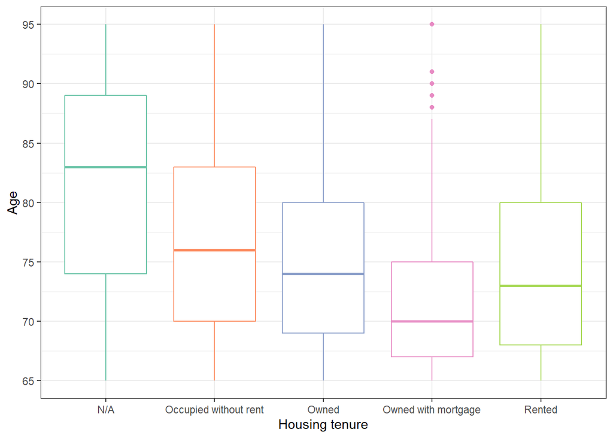

```r
ggplot(person_data,
       aes(x = TEN_label,
           y = AGEP,
           color = TEN_label)) +
  geom_boxplot() +
  scale_x_discrete(name = "Housing tenure",
                    labels = c("N/A",
                               "Occupied without rent",
                               "Owned",
                               "Owned with mortgage",
                               "Rented")) +
  scale_y_continuous(name = "Age",
                     breaks = seq(60, 100, by = 5)) +
  scale_color_brewer(palette="Set2") +
  theme_bw() +
  theme(legend.position = "none")
```

## 5. Violin plot with scatter plot: Housing tenure by household size

While this figure has the same issue mentioned earlier with the other scatter plots, I think its helpful to since it shows how many people exist within each category of housing tenure and household size. Even though this high concentration at points does not allow for an easy understanding of the shape of the violin plot, I think it still reveals important takeaways. These include: the largest households are owned with mortgage, and all N/A housing tenures contain just one person. I believe this further supports my thought that these individuals are living in assisted living facilities.

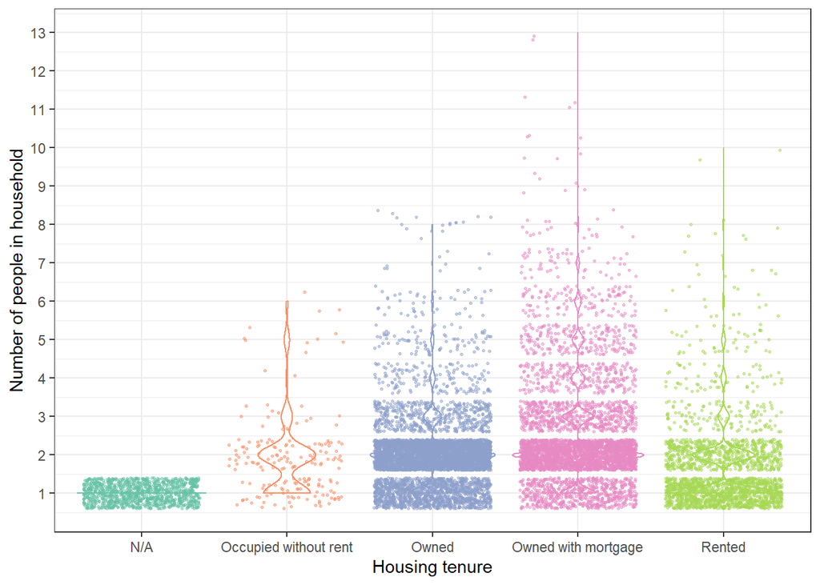

```r
ggplot(person_data,
       aes(x = TEN_label,
           y = NP,
           color = TEN_label)) +
  geom_violin() +
  geom_point(position = "jitter",
             alpha = 0.5,
             size = 0.5) +
  scale_x_discrete(name = "Housing tenure",
                    labels = c("N/A",
                               "Occupied without rent",
                               "Owned",
                               "Owned with mortgage",
                               "Rented")) +
  scale_y_continuous(name = "Number of people in household",
                     breaks = seq(1, 15, by = 1)) +
  scale_color_brewer (palette = "Set2") +
  theme_bw() +
  theme(legend.position = "none")
```

## 6. Violin plot: Housing tenure by income, using a logarithmic scale

This graph surprises me in how little variation it shows, although perhaps this is because of the logarithmic scale. There are differences, though, including the fact that the N/A housing tenure group has the least variation in income, and home owners (both those who own their homes and those who have mortgages) have the greatest variation in income.

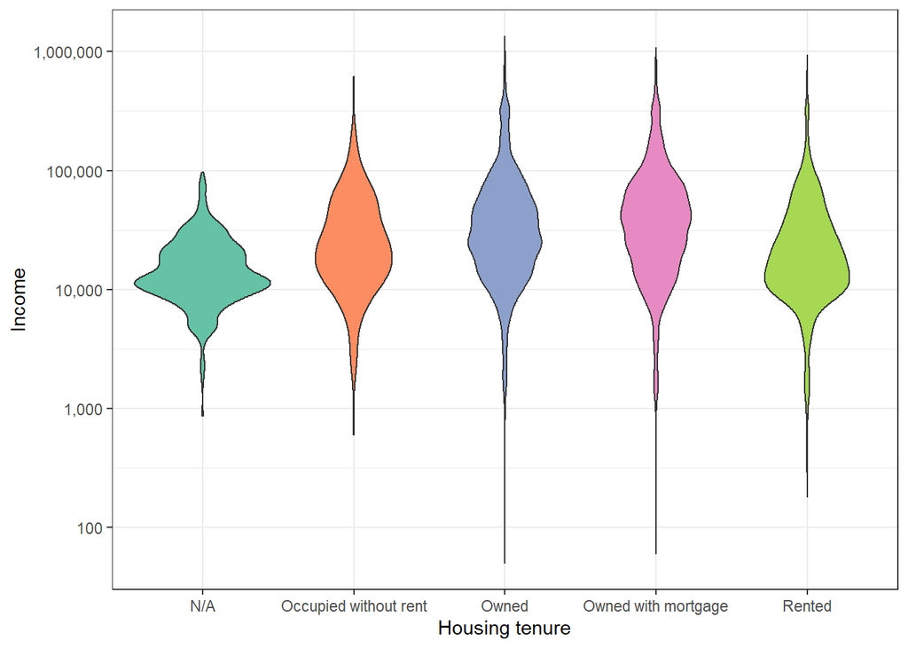

```r
ggplot(person_data,
       aes(x = TEN_label,
           y = PINCP,
           fill = TEN_label)) +
  geom_violin() +
  scale_x_discrete(name = "Housing tenure",
                    labels = c("N/A",
                               "Occupied without rent",
                               "Owned",
                               "Owned with mortgage",
                               "Rented")) +
  scale_y_continuous(name = "Income",
                     trans = "log",
                     breaks = c(10, 100, 1000, 10000, 100000, 1000000),
                     labels = c("10", "100", "1,000", "10,000", "100,000", "1,000,000")) +
  scale_fill_brewer(palette="Set2") +
  theme_bw() +
  theme(legend.position = "none")
```

## 7. Scatter plot: Household size by income, using a logarithmic scale

Again, this chart has a similar issue as previous charts that use scatter plots for household data, That being said, I believe it shows that income variation is the greatest for smaller households, and that, for the most part, incomes decrease as household size increases.

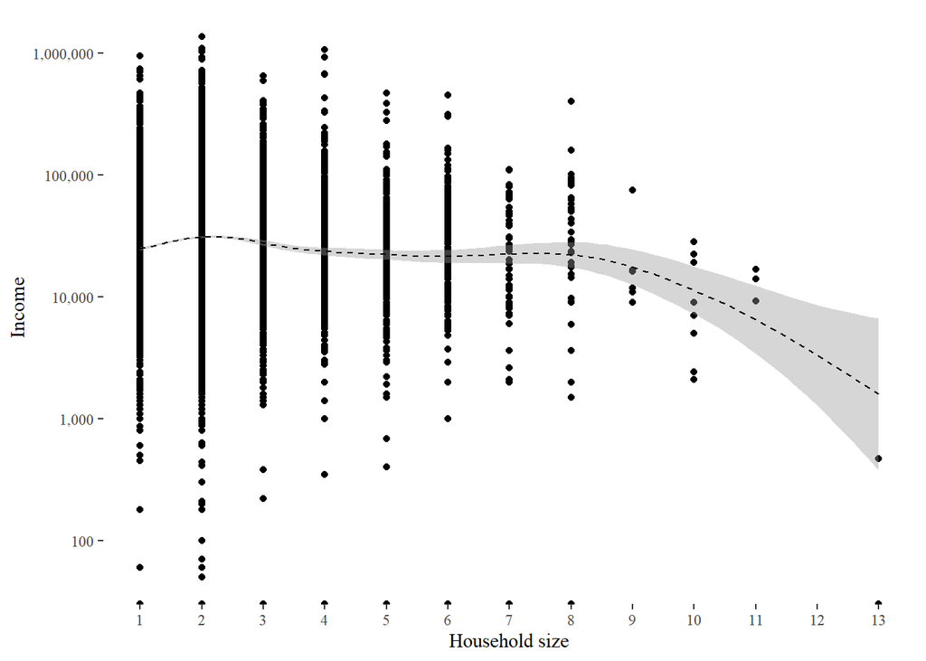

```r
ggplot(person_data,
       aes(x = NP,
           y = PINCP)) +
  geom_point() +
  stat_smooth(color = "black", linetype = 2, size = 0.5) +
  scale_x_continuous(name = "Household size",
                     breaks = seq(1, 20, by = 1)) +
  scale_y_continuous(name = "Income",
                     trans = "log",
                     breaks = c(0, 10, 100, 1000, 10000, 100000, 1000000),
                     labels = c("0", "10", "100", "1,000", "10,000", "100,000", "1,000,000"))+
  theme_tufte()
```

## 8. Dot plot: Race and household size

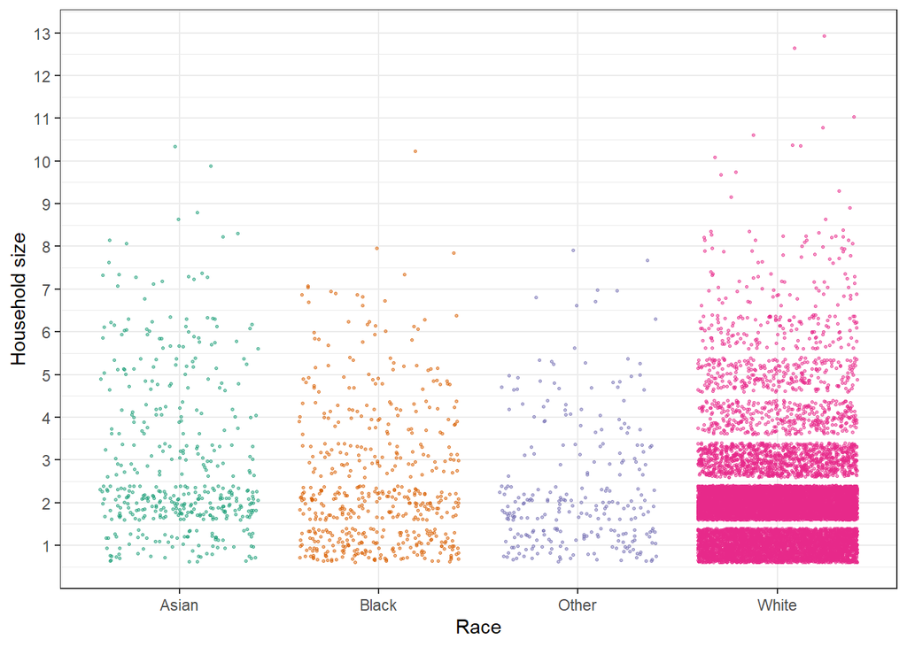

```r
ggplot(person_data,
       aes(x = Race,
           y = NP,
           color = Race)) +
  geom_point(position = "jitter",
             size = 0.5,
             alpha = 0.5) +
  scale_x_discrete(name = "Race") +
  scale_y_continuous((name = "Household size"),
                     breaks = seq(1, 20, by = 1)) +
  scale_color_brewer(palette="Dark2") +
  theme_bw() +
  theme(legend.position = "none")
```

## 9. Stacked bar chart: Race and housing tenure

This chart is also limited in its visualization due to the large number of White folks in the sample. While its hard to parse out the differences in housing tenure among Asian, Black, and Other races, we can clearly see the differences in housing tenure for White people.

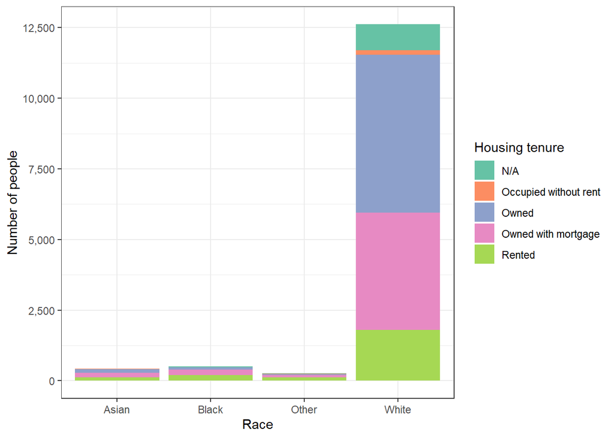

```r
ggplot(person_data, aes(x = Race, fill = TEN_label)) +
  geom_bar() +
  scale_y_continuous(name = "Number of people",
                     breaks = c(0, 2500, 5000, 7500, 10000, 12500),
                     labels = c("0", "2,500", "5,000", "7,500", "10,000", "12,500")) +
  scale_x_discrete(name = "Race") +
  scale_fill_brewer(name="Housing tenure",
                    labels = c("N/A",
                               "Occupied without rent",
                               "Owned",
                               "Owned with mortgage",
                               "Rented"),
                    palette = "Set2")+
  theme_bw()
```

## 10. Bar charts: Race and housing tenure

### Bar cart with dodge

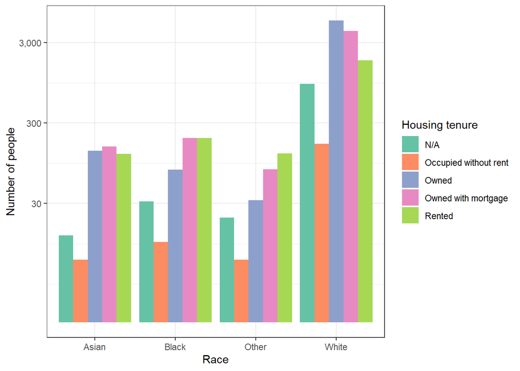

```r
ggplot(person_data, aes(x = Race, fill = TEN_label)) +
  geom_bar(position = "dodge") +
  scale_y_continuous(name = "Number of people",
                     trans = "log",
                     breaks = c(30, 300, 3000),
                     labels= c("30", "300", "3,000")) +
  scale_x_discrete(name = "Race") +
  scale_fill_brewer(name = "Housing tenure",
                    labels = c("N/A",
                               "Occupied without rent",
                               "Owned",
                               "Owned with mortgage",
                               "Rented"),
                    palette="Set2")+
  theme_bw()
```

### Bar chart without dodge, utilizing fill

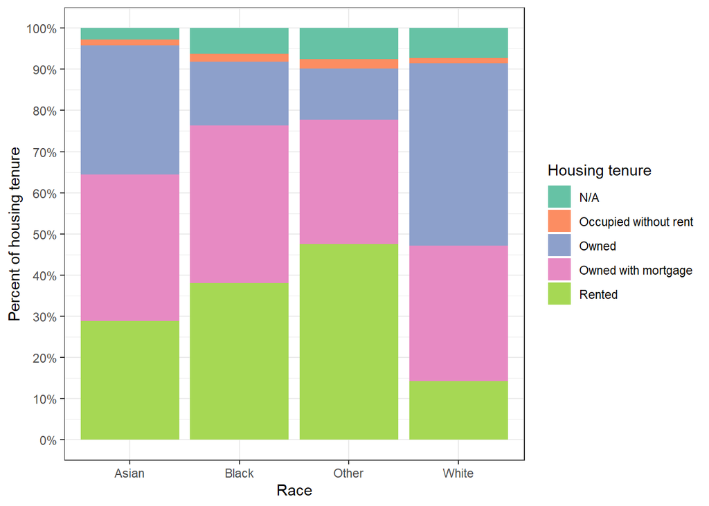

```r
ggplot(person_data, aes(x = Race, fill = TEN_label)) +
  geom_bar(position = "fill") +
  scale_y_continuous(name = "Percent of housing tenure",
                     breaks = seq(0, 1, by = 0.1),
                     labels = paste(seq(0,100, by = 10), "%", sep ="")) +
  scale_x_discrete(name = "Race") +
  scale_fill_brewer (name = "Housing tenure",
                    labels = c("N/A",
                               "Occupied without rent",
                               "Owned",
                               "Owned with mortgage",
                               "Rented"),
                     palette="Set2")+
  theme_bw()
```